# A Data Science Tutorial

Chanh Tran

May 12, 2019

# A Beginner’s Guide to Anaylzing Basketball Statistics : How does height correlate with an NBA player’s skills? How has scoring changed over time?

[figure not shown]

The Greatest Basketball Player of All Time!

# Introduction

In the world of professional sports, data and data analysis is becoming increasingly more important. Statistics are by far the number one tool that scouts, coaches and fans use to analyze sports. Think about the last time that you’ve watched a sports game. I can guarantee that everytime a game is being played, the anouncers will bring up statistics in their commentary in critique of the game. Statistics are used in sports to evaluate players, teams and even the whole entire league! This is especially true in the National Basketball Association (NBA) where teams are increasingly using statistics and data analysis to construct the best team to win and maintain a competitive edge. We assume that the reader is familiar with the sport of basketball. If you don’t know what basketball is however, you can learn more from the link {r} [What is Basketball?] (https://en.wikipedia.org/wiki/Basketball). In this tutorial, we will be guiding the user through phases such as; Gathering Data, Tidying Data, Handling missing Data, Exploratory Data Analysis and Statistical Learning. We will be working with NBA season statistics and Individual Player statistics, where we will be analyzing the data to answer the questions;

### How does height correlate with player’s passing, rebounding and scoring skills?

### Are NBA players scoring more now than before?

By the end of this tutorial, the reader should havr a brief understanding of Data Science and apply the skills learned in this tutorial (Tidying Data, Data Analysis, Statistical Learning) to other data sets that the reader will encounter. I encourage the reader to apply the skills learned in this tutorial on other sports data sets to verify a hypotheses, etc.

The link below lists and thoroughly explains all the stats that we will be working with in this tutorial. [Basketball Statistics](https://en.wikipedia.org/wiki/Basketball_statistics)

A video showing the game of basketball being played can be found below; [Lebron James Highlights](https://www.youtube.com/watch?v=7Vre_nWbPxk)

# Importing Libraries

In this tutorial, we shall be using R, which is considered one of the most popular programming languages for Data Analysis. The reader should begin by setting up R on their computer. Below is a video tutorial for setting up R and Rstudio.

[Install For Windows](https://www.youtube.com/watch?v=9-RrkJQQYqY) [Install For Mac](https://www.youtube.com/watch?v=1PsPfMaLWSk)

We first begin by loading the necessary libraries; Dplyer, TidyVerse and GGPlot2. If you don’t have these libaries installed, simply type “install.packages(library_name)” into the R console.

# Gathering the Data

Next, we shall be gathering the data necessary for this tutorial. We downloaded this data set from the website below. To download the data, the reader will have to make an account. When downloading the data, the Zip file will include 3 CSV files. We shall only use 2 of the CSV files( SeasonStats.csv and PlayerMeasurement.csv)

[Data Website](https://www.kaggle.com/drgilermo/nba-players-stats)

The reader should replace the parameters with the locations of the files on their computers.

```r
IndividualPlayerStats <- read_csv("C:/Users/Ctran/Desktop/CMSC320Final/SeasonStats.csv")


PlayerMeasurements <- read_csv("C:/Users/Ctran/Desktop/CMSC320Final/PlayerMeasurements.csv")
```

# Tidying the Data

In this next step, we shall be Tidying the data. By this, we mean that we shall be dealing with common problems that usually come with raw datasets. Usually raw datasets are messy. For example, a lot of values will appear as N/A, Column headers are values instead of variable names and multiple variables may be stored in one column. Below, we shall be combining the 2 seperate data frames we have created above into one dataframe that we can used to perform our analysis.

The first step that we shall do is filter the data in each of the data frames to only include data from the year 2000 and onward. We have chosen 2000 as the starting year of our data because a lot of statistics weren’t measured in the 1990s.The result of this filtering will be a more cohesive dataset.

In addition to this, we shall be peforming string operations on our data set to make the data uniform throughout each of the two data frames. This is necessary because it will make it much easier for us to join the individual data frames in one. Also this important because we want to make the data more readable.

[More on Tidy Data](https://vita.had.co.nz/papers/tidy-data.pdf)

```r
IndividualPlayerStats$blank2 = NULL
# Get rid of unnecessary column
IndividualPlayerStats <- IndividualPlayerStats %>% filter(Year >= 2000)
#We filter the data set for Years >= 2000
colnames(IndividualPlayerStats)[2] <- "name"
#We rename the column so we join the data frames later on


PlayerMeasurements$year_start = PlayerMeasurements$year_end = PlayerMeasurements$position =
  PlayerMeasurements$birth_date = PlayerMeasurements$college = NULL
#Rid of unnecessary columns
PlayerMeasurements <- PlayerMeasurements %>%
  mutate(height = (as.numeric(substring(height, 1, 1)) * 12 +  as.numeric(substring(height, 3)))/12.0)
#Use String operations to turn height into a numeric variable

#Join Data Frames
data_Frame <- merge(IndividualPlayerStats, PlayerMeasurements, by = "name")
data_Frame$blanl = NULL

as_tibble(data_Frame) %>%
  slice(1:10) # Display the table
```

```
## # A tibble: 10 x 52
##    name   Year Pos     Age Tm        G    GS    MP   PER `TS%` `3PAr`   FTr
##    <chr> <dbl> <chr> <dbl> <chr> <dbl> <dbl> <dbl> <dbl> <dbl>  <dbl> <dbl>
##  1 A.C.~  2000 PF       36 LAL      82    82  1929  11.2 0.482  0.01  0.245
##  2 A.C.~  2001 PF       37 MIA      82     1  1411  11.2 0.492  0.019 0.343
##  3 A.J.~  2000 C        23 CLE       8     0    61  -0.4 0.19   0     0
##  4 A.J.~  2003 PG       24 GSW       2     0     9  -9   0      0.25  0
##  5 A.J.~  2002 PG       23 CHI      45     6   607  11.8 0.477  0.504 0.111
##  6 A.J.~  2001 PG       22 CHI      33     8   630  10.3 0.495  0.359 0.094
##  7 A.J.~  2017 C        24 DAL      22     0   163   8.4 0.472  0.238 0.476
##  8 A.J.~  2012 PG       25 IND      44     1   568  11.5 0.454  0.506 0.201
##  9 A.J.~  2014 SG       27 MIN      28     0    99   9.7 0.469  0.478 0.043
## 10 A.J.~  2015 PG       28 PHO       5     0    44  -1.6 0.214  0.5   0
## # ... with 40 more variables: `ORB%` <dbl>, `DRB%` <dbl>, `TRB%` <dbl>,
## #   `AST%` <dbl>, `STL%` <dbl>, `BLK%` <dbl>, `TOV%` <dbl>, `USG%` <dbl>,
## #   OWS <dbl>, DWS <dbl>, WS <dbl>, `WS/48` <dbl>, OBPM <dbl>, DBPM <dbl>,
## #   BPM <dbl>, VORP <dbl>, FG <dbl>, FGA <dbl>, `FG%` <dbl>, `3P` <dbl>,
## #   `3PA` <dbl>, `3P%` <dbl>, `2P` <dbl>, `2PA` <dbl>, `2P%` <dbl>,
## #   `eFG%` <dbl>, FT <dbl>, FTA <dbl>, `FT%` <dbl>, ORB <dbl>, DRB <dbl>,
## #   TRB <dbl>, AST <dbl>, STL <dbl>, BLK <dbl>, TOV <dbl>, PF <dbl>,
## #   PTS <dbl>, height <dbl>, weight <dbl>
```

# Handling Missing Data

Now we have all our data inside one single Data Frame! However despite this, there are still some problems with our data. Alot of the columns have missing values. To handle the missing data, we will be replacing “NA” with ther average of the columns.` For example, if a player’s height is N/A, we replace it with the mean of the heights.

```r
#This code replace all missing data with the mean of the corresponding column.

for(i in 10:ncol(data_Frame)){
 data_Frame[is.na(data_Frame[,i]), i] <- mean(data_Frame[,i], na.rm = TRUE)
}

#data_Frame
as_tibble(data_Frame) %>%
  slice(1:10) # Display the table
```

```
## # A tibble: 10 x 52
##    name   Year Pos     Age Tm        G    GS    MP   PER `TS%` `3PAr`   FTr
##    <chr> <dbl> <chr> <dbl> <chr> <dbl> <dbl> <dbl> <dbl> <dbl>  <dbl> <dbl>
##  1 A.C.~  2000 PF       36 LAL      82    82  1929  11.2 0.482  0.01  0.245
##  2 A.C.~  2001 PF       37 MIA      82     1  1411  11.2 0.492  0.019 0.343
##  3 A.J.~  2000 C        23 CLE       8     0    61  -0.4 0.19   0     0
##  4 A.J.~  2003 PG       24 GSW       2     0     9  -9   0      0.25  0
##  5 A.J.~  2002 PG       23 CHI      45     6   607  11.8 0.477  0.504 0.111
##  6 A.J.~  2001 PG       22 CHI      33     8   630  10.3 0.495  0.359 0.094
##  7 A.J.~  2017 C        24 DAL      22     0   163   8.4 0.472  0.238 0.476
##  8 A.J.~  2012 PG       25 IND      44     1   568  11.5 0.454  0.506 0.201
##  9 A.J.~  2014 SG       27 MIN      28     0    99   9.7 0.469  0.478 0.043
## 10 A.J.~  2015 PG       28 PHO       5     0    44  -1.6 0.214  0.5   0
## # ... with 40 more variables: `ORB%` <dbl>, `DRB%` <dbl>, `TRB%` <dbl>,
## #   `AST%` <dbl>, `STL%` <dbl>, `BLK%` <dbl>, `TOV%` <dbl>, `USG%` <dbl>,
## #   OWS <dbl>, DWS <dbl>, WS <dbl>, `WS/48` <dbl>, OBPM <dbl>, DBPM <dbl>,
## #   BPM <dbl>, VORP <dbl>, FG <dbl>, FGA <dbl>, `FG%` <dbl>, `3P` <dbl>,
## #   `3PA` <dbl>, `3P%` <dbl>, `2P` <dbl>, `2PA` <dbl>, `2P%` <dbl>,
## #   `eFG%` <dbl>, FT <dbl>, FTA <dbl>, `FT%` <dbl>, ORB <dbl>, DRB <dbl>,
## #   TRB <dbl>, AST <dbl>, STL <dbl>, BLK <dbl>, TOV <dbl>, PF <dbl>,
## #   PTS <dbl>, height <dbl>, weight <dbl>
```

We shall use the mutate function to create the new columns;

[Mutate Function](https://dplyr.tidyverse.org/reference/mutate.html)

```r
data_Frame <- data_Frame %>%
  mutate(PPG = (PTS * 1.0)/G, APG = (AST * 1.0)/G, RPG = ((ORB + DRB) * 1.0)/G)
#Creates new variables

data_Frame <- data_Frame %>% select("name", "Year", "PPG", "APG", "RPG", "height")
#extracts the columns

as_tibble(data_Frame) %>%
  slice(1:10) # Display the table
```

```
## # A tibble: 10 x 6
##    name           Year   PPG   APG   RPG height
##    <chr>         <dbl> <dbl> <dbl> <dbl>  <dbl>
##  1 A.C. Green     2000  5.04 0.976 5.93    6.75
##  2 A.C. Green     2001  4.48 0.476 3.82    6.75
##  3 A.J. Bramlett  2000  1    0     2.75    6.83
##  4 A.J. Guyton    2003  0    1     0       6.08
##  5 A.J. Guyton    2002  5.42 1.8   0.978   6.08
##  6 A.J. Guyton    2001  6    1.94  1.09    6.08
##  7 A.J. Hammons   2017  2.18 0.182 1.64    7
##  8 A.J. Price     2012  3.91 1.95  1.39    6.17
##  9 A.J. Price     2014  1.57 0.464 0.357   6.17
## 10 A.J. Price     2015  1.2  1.2   0.6     6.17
```

Congratulations! Now that we have our Data Frame ready, we can perform our data analysis!

# Exploratory Data Analysis : Visualization/Summarization

[figure not shown]

Manut Bol and Muggsy Bogues

In the first step of our data analysis, we shall analyze the distribution of height in the NBA. In order to acheive this, we shall group by height and summarize the frequency of each particular height. Then, we shall plot the frequency of a particular height (Y - Axis) to the height itself (X - Axis). The plot that we will be utilizing to perform this analysis is a scatter plot.

For more on ggPlot and the functions used in this code bit; [GGPlot Introduction](http://r-statistics.co/Complete-Ggplot2-Tutorial-Part1-With-R-Code.html) [Summarize_Function](https://www.rdocumentation.org/packages/Hmisc/versions/4.2-0/topics/summarize) [Group_By_Function](https://www.rdocumentation.org/packages/dplyr/versions/0.7.8/topics/group_by) [Scatter Plot](https://en.wikipedia.org/wiki/Scatter_plot)

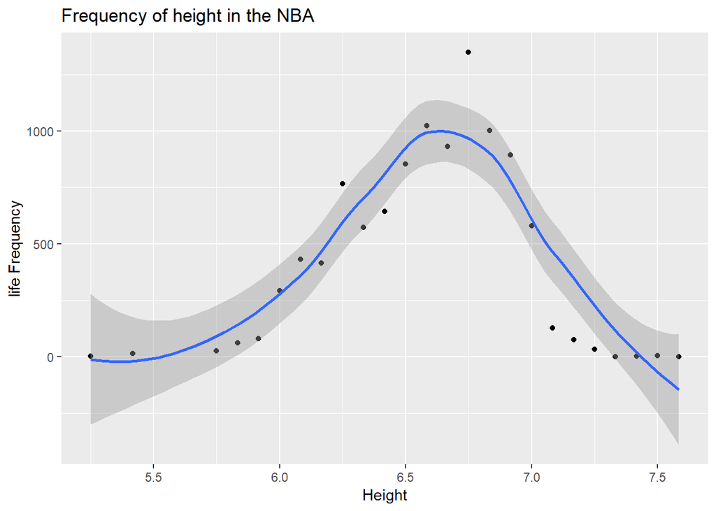

```r
data_Frame %>% group_by(height) %>%
  summarize(frequency = n()) %>%
  ggplot(mapping=aes(x = height, y = frequency)) +
  geom_point() +
  geom_smooth() +
  labs(title="Frequency of height in the NBA",
         x = "Height",
         y = "life Frequency")
```

By observing the plot, we can deduce that the average height in the nba is around 6’7. Lets search up the answer to the average height in the NBA on google and find out how close our analyis is!

For the rest of our Data Analysis, we shall be asking the relationship of Height v.s Rebounds(RPG), Height v.s Scoring(PPG) and Height vs Assists(APG). For each relationship, we shall be using a different type of analysis. We want to expose the reader to as many different data analysis tools as possible.

# Height vs Assists

We shall now analyze height vs Assists. We do that by making a scatter plot of heights(X - Axis) to Assists(Y - Axis).

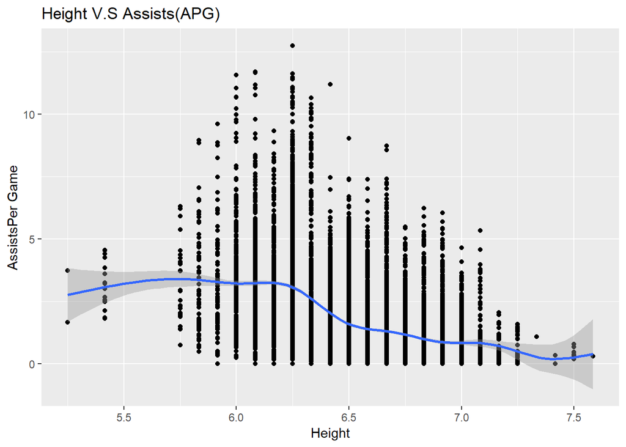

```r
data_Frame %>% group_by(height) %>%
  ggplot(mapping=aes(x = height, y = APG)) +
  geom_point() +
  geom_smooth() +
  labs(title="Height V.S Assists(APG)",
         x = "Height",
         y = "AssistsPer Game")
```

# Standardizing Variables

From the plot above, it is apparent that shorter players tend to be better passers. Sometimes, it is necessary to perform data transformations in order to ease both interpretation of data analyses and the application statistical and machine learning models to a dataset.

For more on standardizing variables; [Standardizing Variables](https://www.r-bloggers.com/standardize-z-score-a-dataframe/)

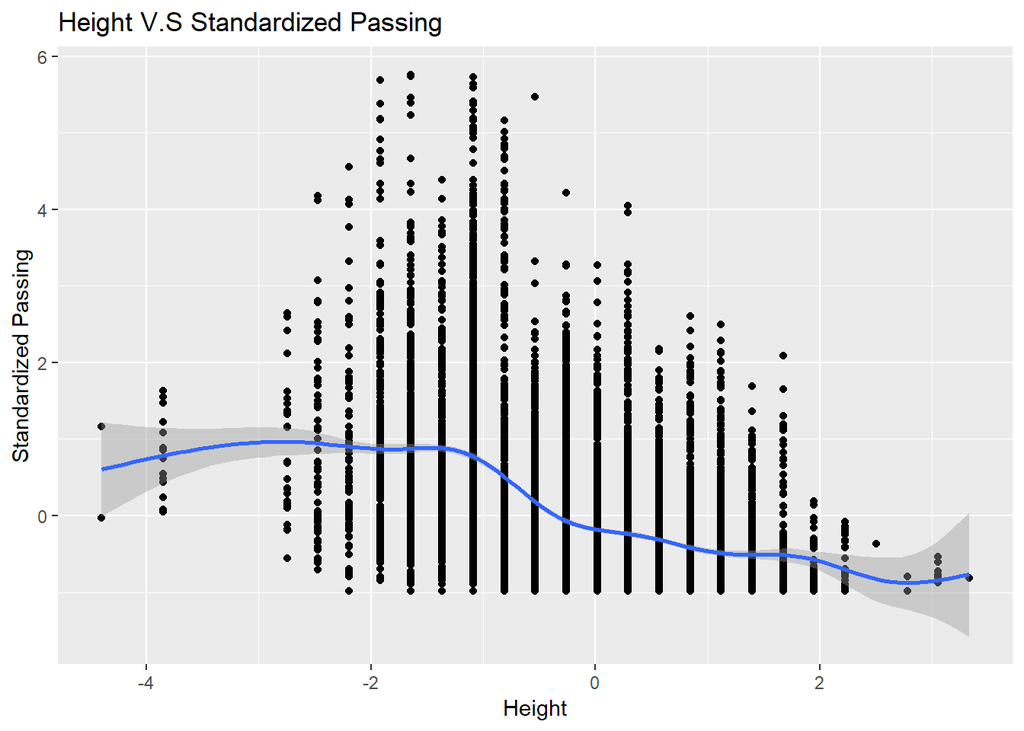

```r
#Standardize Variables
data_Frame_Passing <- data_Frame %>%
  filter(APG <= 12) %>%
  mutate(avgAPG = mean(APG), stdDevAPG = sd(APG)) %>%
  mutate(standardized_APG = (APG - avgAPG)/stdDevAPG)
data_Frame_Passing <- data_Frame_Passing %>%
  mutate(avgH = mean(height), stdDevH = sd(height)) %>%
  mutate(standardized_H = (height - avgH)/stdDevH)


#Plot Data
data_Frame_Passing %>% group_by(standardized_H) %>%
  ggplot(mapping=aes(x = standardized_H, y = standardized_APG)) +
  geom_point() +
  geom_smooth() +
  labs(title="Height V.S Standardized Passing",
         x = "Height",
         y = "Standardized Passing")
```

# Height v.s Scoring

We will now analyze the relationship between height vs scoring. We shall analyze this relationship by using violin plots, which show the probability density of the data at different values. We first discretize the height variable by dividing height into 10 seperate intervals, Then create a violin plot for each individual interval.

[Violin Plots](https://en.wikipedia.org/wiki/Violin_plot) [Discretization](https://en.wikipedia.org/wiki/Discretization_of_continuous_features)

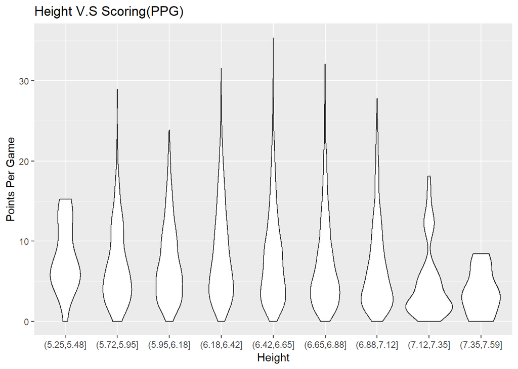

```r
#We break down the height varaible into 10 seperate intervals
data_Frame %>% mutate(heightLevel = cut(height, breaks = 10)) %>%
  group_by(heightLevel) %>%
  ggplot(mapping=aes(x = heightLevel, y = PPG)) +
  geom_violin() +
  labs(title="Height V.S Scoring(PPG)",
         x = "Height",
         y = "Points Per Game")
```

This plot shows us the distribution of scoring is relatively similar throughout all the heights with 7 footers being an exception. Looking at the graph, we can’t really say definitively whether there is a relationship between height and scoring. (Later on in this tutorial, we shall learn about determinining the probability of such a relationship).

# Height v.s Rebounds

Next we shall plot Height v.s Rebounds! This time, we shall be doing a Box Plot. We shall group the data by height, and then make a box plot of the distributions of rebounding for each height. Similar to what we did with violin plots, we will also be discretizing our height variable.

[box_plots](https://en.wikipedia.org/wiki/Box_plot)

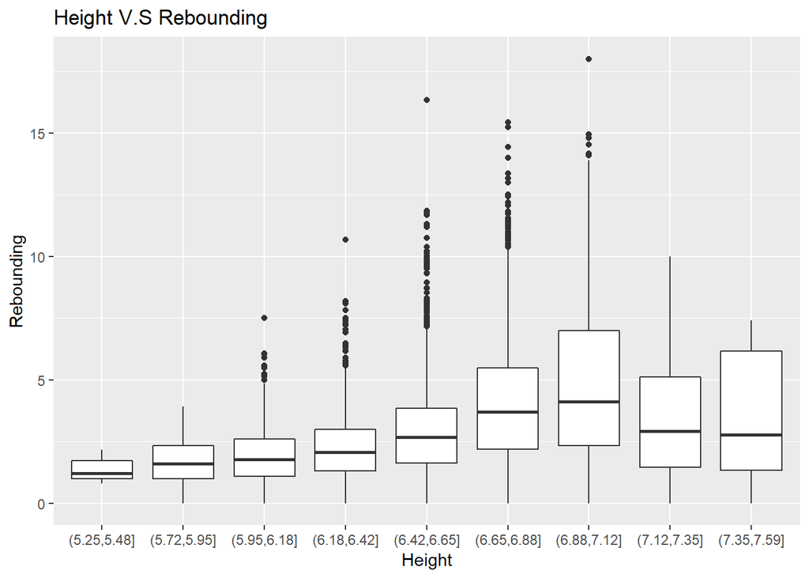

```r
data_Frame %>% mutate(heightLevel = cut(height, breaks = 10)) %>%
  group_by(heightLevel) %>%
  ggplot(mapping=aes(x = heightLevel, y = RPG)) +
  geom_boxplot() + labs(title="Height V.S Rebounding",
         x = "Height",
         y = "Rebounding")
```

# Statistical Learning

## Are players scoring more now than players of the past?

In order to answer this question, we shall make group the players in the data set by the year they played, and find the Average scoring of all players within that year. We shall then make a plot demonstrating the relationship between the year and the Average scoring. We shall then attempt to fit a linear regression curve on the plot.

[Linear Regression](http://r-statistics.co/Linear-Regression.html)

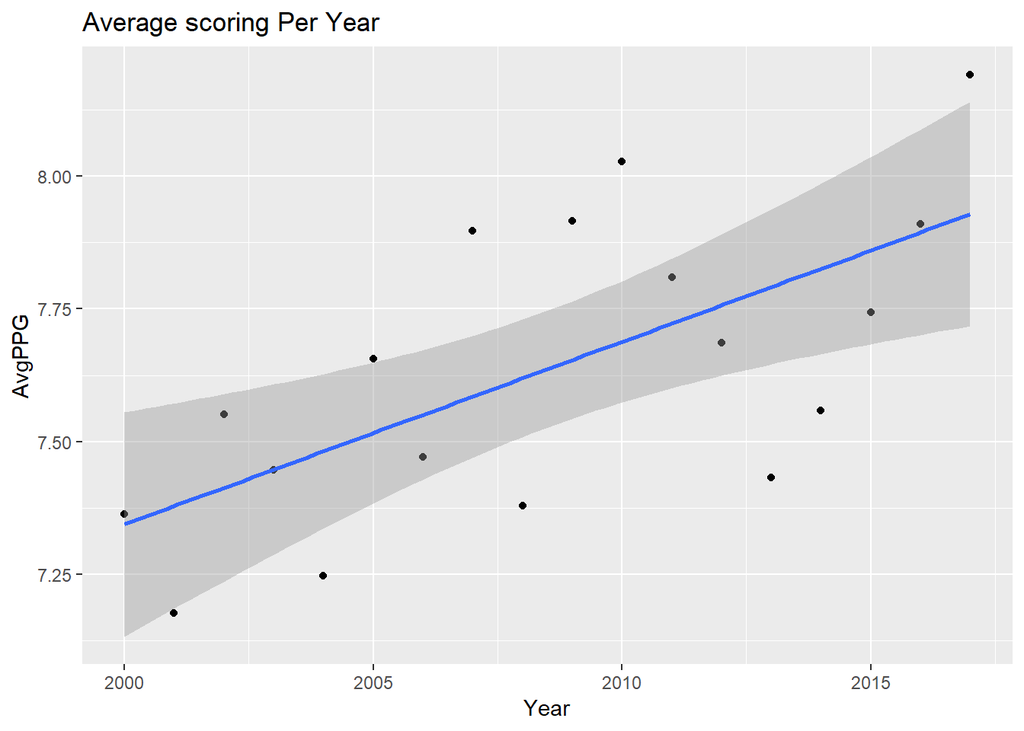

```r
data_Frame %>% group_by(Year) %>%
  summarize(AvgPPG = mean(PPG)) %>%
  ggplot(mapping=aes(x = Year, y = AvgPPG)) +
  ggtitle("Average scoring Per Year") + geom_point() +
  geom_smooth(method = lm)
```

Whenever you’re attempting to demonstrate a linear relationship between two variables, one should try to fit a linear regression curve. The curve on the plot above demonstrates that Average scoring has been on an upward trend since 2000. However, how can we determine the chances that the data isn’t a fluke and that there is an actual linear relationship between the variables?

The next question that we shall be addressing is “How can we determine the probability of some sort of linear relationship between two variables?”" The code below constructs a linear regression model between Year and Average PPG.

```r
library(broom) # library necessary to view the model.
shootingAvg_Frame <- data_Frame %>% group_by(Year) %>%
  summarize(AvgPPG = mean(PPG))


shootingModel <- lm(AvgPPG~Year, data = shootingAvg_Frame)
shootingModel <- shootingModel %>% tidy()
shootingModel
```

```
## # A tibble: 2 x 5
##   term        estimate std.error statistic p.value
##   <chr>          <dbl>     <dbl>     <dbl>   <dbl>
## 1 (Intercept) -61.4      20.1        -3.06 0.00754
## 2 Year          0.0344    0.0100      3.44 0.00339
```

The p-Values are important because we can a linear model to be statistically significant only when both these p-Values are less then the pre-determined statistical significance level, which is usually 0.05. When p Value is less than significance level (< 0.05), we can safely reject the null hypothesis. Since the p-values are less than .05, we can be confident that this model is statistically signifcant and that there is a relationship between Year and the Overall Average scoring for that year.

# Exercise for the reader

## Create a linear regression model between height and scoring and determine if the model is statistically significant.

# Conclusion

Overall we have analyzed NBA statistics since 2000 and performed many different kinds of operations in order to arrive at differenet conclusions. These operations and methods are integral for the NBA where statistics can give a unique insight that none else can. These kinds of statistics are extremely important because they provide evidence for different kinds of conclusions. For example, we could easily perform a data analysis to see if certain players do worse against certain team, or if taller teams do better against shorter teams. Statistics opens the door to answering these kinds of questions.However, the skills learned in this tutorial is not limited to sports statistics, but can be applied elsewhere too.

Overall, I hope you enjoyed working through this tutorial, and encourage you to expand on concepts explored in this subject. Basketball and sports have been a huge part of my childhood, and these skills will provide me unrivaled insight into the game.

Citations

# References

http://www.hcbravo.org/IntroDataSci/

http://r-statistics.co/Linear-Regression.html

https://www.kaggle.com/datasets?utm_medium=paid&utm_source=google.com+search&utm_campaign=datasets&gclid=CjwKCAjw5pPnBRBJEiwAULZKvmAL0P3lvEBPEnK3jlPmiIT60vX674LWCk3l5PwnOpCh95N2J9LrMRoC4qUQAvD_BwE

https://www.nba.com/